# Disparidades en la valorización de la Canasta Básica Alimentaria relevada por el INDEC y el Índice Barrial de Precios en el Gran Buenos Aires entre enero de 2017 a diciembre 2023.

## Disparidades en la valorización de la Canasta Básica Alimentaria relevada por el INDEC y el Índice Barrial de Precios en el Gran Buenos Aires entre enero de 2017 a diciembre 2023.

D’Urbano Guim, Juan | Gomez Vargas, Andrea | Iummato, Luciana

Indicadores Económicos  
Maestría en Generación y Análisis de Información Estadística  
UNTREF

28 de agosto de 2024

## Planteamiento del problema y Objetivo

### Objetivo general:

Analizar las diferencias en el comportamiento de los precios de la Canasta Básica Alimentaria (CBA) relevado por INDEC y el Índice Barrial de Precios (IBP) entre enero de 2017 a diciembre 2023, en la zona del Gran Buenos Aires.

### Objetivos específicos:

- Comparar las tendencias de la variación de precios de la Canasta Alimentaria relevada por el INDEC y el IBP entre 2017 a 2023.
- Comparar las tendencias de variación de precios en productos alimenticios seleccionados de la Canasta Alimentaria entre 2017 a 2023.

## Estado actual del conocimiento sobre el tema

- Procesos inflacionarios incrementan sustancialmente los índices de pobreza. Vínculo entre la variación de precios, la proporción del gasto en alimentos y la pobreza. Impacto diferencial en familias con diversos ingresos.
- Definiciones de la pobreza, método de medición indirecta a través de canastas (INDEC).
- Relevamiento de canastas alimentarias en zonas vulnerables o barrios populares (ISEPCI).

## Metodología

- *Período de análisis:* enero 2017 a diciembre 2023.
- *Cobertura geográfica:*
  - INDEC: Ciudad Autónoma de Buenos Aires y 24 partidos del Gran Buenos Aires
  - ISEPCI: 24 partidos del Gran Buenos Aires

### Indicadores/variables:

- Valorización Mensual de la Canasta Básica Alimentaria (CBA) y de la Canasta Básica Total (CBT) para hogar tipo 2 en el Gran Buenos Aires.
- Variación relativa porcentual respecto al mes anterior de la Canasta Básica Alimentaria (CBA) y de la Canasta Básica Total (CBT) para hogar tipo 2 en el Gran Buenos Aires.
- Precios al consumidor de una selección de alimentos, bebidas y otros artículos para el GBA.
- Variación de precios de los productos que integran la Canasta Básica en el GBA.

## Primeros resultados

- Comparativo 2023
- CBA
- CBT

**Cuadro 1:** Valorización mensual y variación relativa porcentual respecto al mes anterior de la Canasta Básica Alimentaria (CBA) y de la Canasta Básica Total (CBT) para hogar tipo 2 en el Gran Buenos Aires. Año 2023.

| mes | **INDEC** CBA | **INDEC** variación relativa al mes anterior | **INDEC** CBT | **INDEC** variación relativa al mes anterior | **ISEPCI** CBA | **ISEPCI** variación relativa al mes anterior | **ISEPCI** CBT | **ISEPCI** variación relativa al mes anterior |
| --- | --- | --- | --- | --- | --- | --- | --- | --- |
| Enero | 72.043,47 | 7,2 | 163.538,68 | 7,2 | 68.094,31 | 6,2 | 154.574,08 | 5,7 |
| Febrero | 80.483,13 | 11,7 | 177.062,87 | 8,3 | 77.523,67 | 13,8 | 175.978,70 | 13,8 |
| Marzo | 87.719,29 | 9,0 | 191.228,05 | 8,0 | 84.478,10 | 9,0 | 190.920,50 | 8,5 |
| Abril | 94.148,47 | 7,3 | 203.360,69 | 6,3 | 91.347,29 | 8,1 | 203.704,50 | 6,7 |
| Mayo | 99.052,64 | 5,2 | 217.915,79 | 7,2 | 95.665,51 | 4,7 | 214.003,08 | 5,1 |
| Junio | 104.227,28 | 5,2 | 232.426,83 | 6,7 | 102.266,27 | 6,9 | 228.053,78 | 6,6 |
| Julio | 111.642,16 | 7,1 | 248.962,01 | 7,1 | 110.079,25 | 7,6 | 245.476,73 | 7,6 |
| Agosto | 130.590,35 | 17,0 | 284.686,95 | 14,3 | 139.789,65 | 27,0 | 311.730,92 | 27,0 |
| Septiembre | 147.880,57 | 13,2 | 319.422,04 | 12,2 | 143.562,96 | 2,7 | 320.145,40 | 2,7 |
| Octubre | 160.602,53 | 8,6 | 345.295,45 | 8,1 | 159.153,97 | 10,9 | 343.772,55 | 7,4 |
| Noviembre | 185.050,40 | 15,2 | 390.456,32 | 13,1 | 182.905,48 | 14,9 | 393.246,07 | 14,4 |
| Diciembre | 240.678,80 | 30,1 | 495.798,32 | 27,0 | 271.572,37 | 48,5 | 573.017,70 | 45,7 |

**Fuente:** Elaboración propia con base a los informes publicados por INDEC e ISEPCI

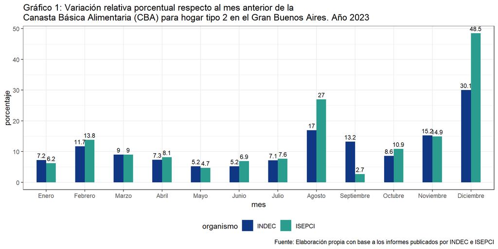

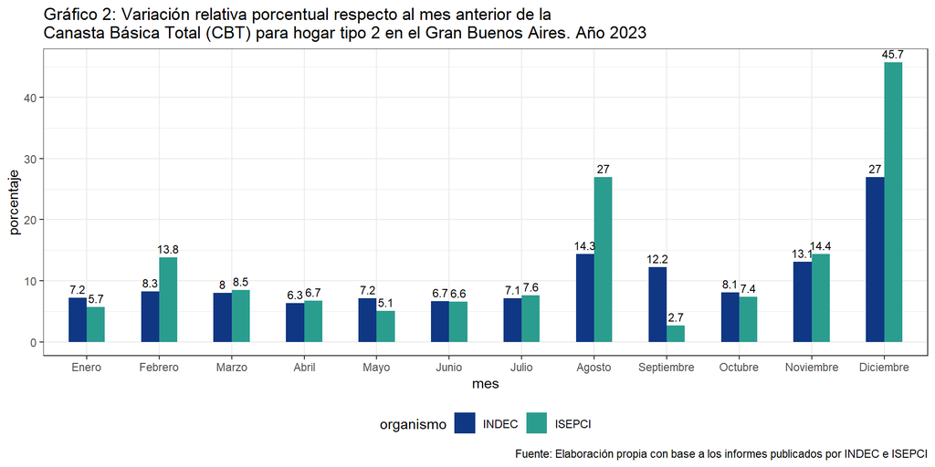

## Fuentes de información

| Organismo | Fuente de Información | Período |
| --- | --- | --- |
| INDEC | Informes técnicos: Valorización mensual de la canasta básica alimentaria y de la canasta básica total. | Enero 2017 a diciembre 2023 |
| INDEC | Canasta básica alimentaria y canasta básica total. Resultados mensuales expresados en pesos por adulto equivalente y variaciones porcentuales. Abril de 2016 a julio de 2024 | Enero 2017 a diciembre 2023 |
| INDEC | Informes técnicos: Índice de precios al consumidor (IPC) | Enero 2017 a diciembre 2023 |
| ISEPCI | IBP CONURBANO BONAERENSE. Canasta Básica Alimentaria (CBA) y Canasta Básica Total (CBT). valores históricos | Enero 2017 a diciembre 2023 |